# Lecture5 Notes: Exploratory data analysis

Wenjie Qi

2021/10/5

# Data types

1. continuous
2. discrete
3. categorical
4. binary
5. ordinal

data set = data sample

# Estimating the overall location of a feature in a data set

## Estimates of location for categorical data

Which single value is most representative or typical? For categorical data the natural answer is the sample mode. The sample mode is the value which occurs with the highest frequency for a feature within a data set.

```r
library(tidyverse)
library(palmerpenguins)
library(modeest)
library(hydroTSM)
```

```r
library(ggplot2)
library(tibble)
mfv1(penguins$species)  # most frequent value
```

```
## [1] Adelie
## Levels: Adelie Chinstrap Gentoo
```

## Estimates of location for continuous data

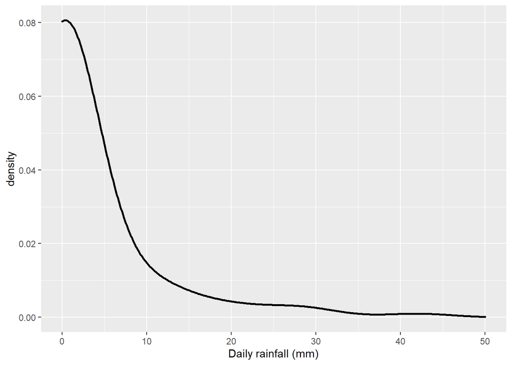

```r
data("SanMartinoPPts")
rainfall <- as.vector(window(SanMartinoPPts, start=as.Date("1985-01-01"), end=as.Date("1985-01-01")+99))

ggplot(tibble(rainfall), aes(x=rainfall)) + xlab("Daily rainfall (mm)") + geom_density(adjust=10, size=1) + xlim(c(0, 50))
```

Which single number can best represent “typical rainfall”?

## The sample mean

```r
mean(rainfall, na.rm=1)
```

```
## [1] 3.228
```

## The sample median

```r
median(rainfall, na.rm=1)
```

```
## [1] 0
```

## Outliers

An outlier is a value in a data set which differs substantially from other values. 1. A faithful representation of genuinely anomalous event. 2. An error in the data resulting from problems in measurement, recording etc.

## Comparing the sample median and the sample mean

1. A major advantage of the median over the mean is that it’s robust to small corruptions in the data set.
2. The sample median effectively ignores a large section of the data set, unlike mean. And this makes it difficult to aggregated medians from multiple sources.

## The trimmed sample mean

the mean computed after removing a prescribed fraction of the data

```r
mean(rainfall, na.rm = 1, trim = 0.05)
```

```
## [1] 1.953333
```

## Examples

###Estimates of location for penguins

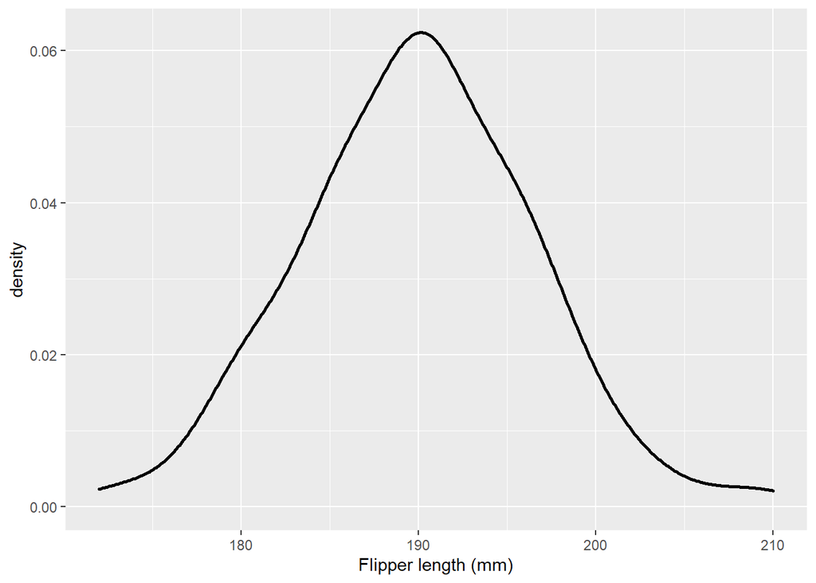

```r
flippers <- penguins %>%
  filter(species == "Adelie") %>%
  select(flipper_length_mm) %>%
  unlist() %>%  # turn a list into vector
  as.vector()  # as.vector, a generic, attempts to coerce its argument into a vector of mode mode (the default is to coerce to whichever vector mode is most convenient): if the result is atomic all attributes are removed.

ggplot(tibble(flippers), aes(x=flippers)) + xlab("Flipper length (mm)") + geom_density(adjust=1, size=1)
```

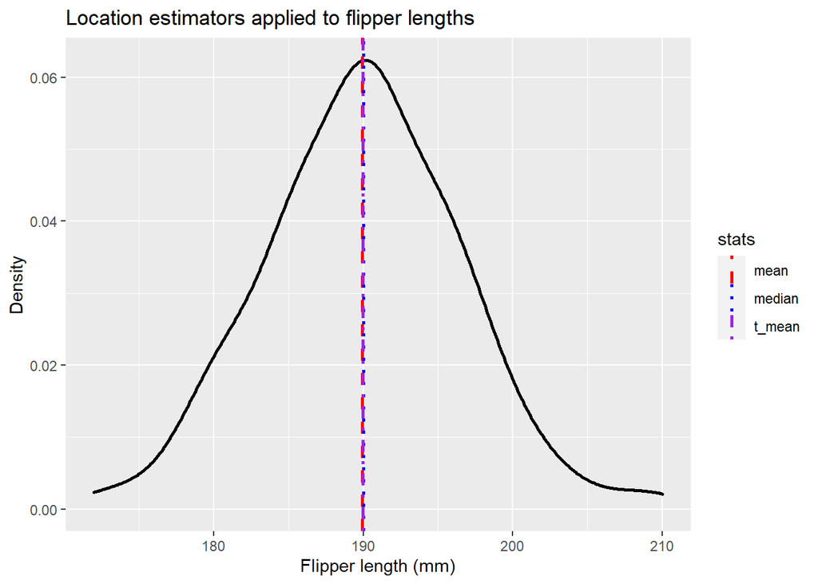

```r
ggplot(tibble(flippers), aes(x=flippers)) +
  geom_density(adjust=1, size=1) + xlab("Flipper length (mm)") + ylab("Density") +
  geom_vline(aes(xintercept = mean(flippers, na.rm=1), linetype="mean", color="mean"), size=1) +
  geom_vline(aes(xintercept = median(flippers, na.rm=1), linetype="median", color="median"), size=1) +
  geom_vline(aes(xintercept = mean(flippers,na.rm=1, trim=0.25), linetype="t_mean", color="t_mean"), size=1) +
  scale_linetype_manual(name="stats", values=c(mean="dashed", median="dotted", t_mean="dotdash")) +
  scale_color_manual(name="stats", values=c(mean="red", median="blue", t_mean="purple")) +
  ggtitle("Location estimators applied to flipper lengths")
```

### Estimates of location for rainfall data

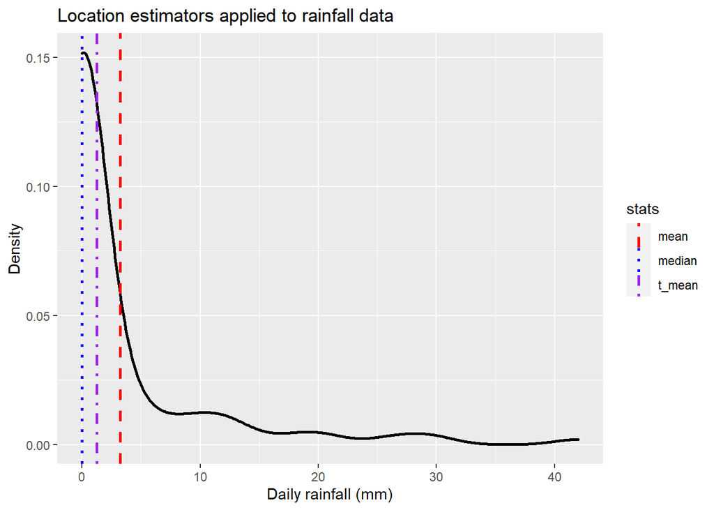

```r
ggplot(tibble(rainfall), aes(x=rainfall)) +
  geom_density(adjust=5, size=1) + xlab("Daily rainfall (mm)") + ylab("Density") +
  geom_vline(aes(xintercept = mean(rainfall, na.rm=1), linetype="mean", color="mean"), size=1) +
  geom_vline(aes(xintercept = median(rainfall, na.rm=1), linetype="median", color="median"), size=1) +
  geom_vline(aes(xintercept = mean(rainfall,na.rm=1, trim=0.1), linetype="t_mean", color="t_mean"), size=1) +
  scale_linetype_manual(name="stats", values=c(mean="dashed", median="dotted", t_mean="dotdash")) +
  scale_color_manual(name="stats", values=c(mean="red", median="blue", t_mean="purple")) +
  ggtitle("Location estimators applied to rainfall data")
```

## Sample quantiles and sample percentiles

```r
quantile(flippers, na.rm=1, probs=seq(from=0, to=1, by=0.1))
```

```
##   0%  10%  20%  30%  40%  50%  60%  70%  80%  90% 100%
##  172  181  185  187  189  190  191  193  195  198  210
```

### In penguins

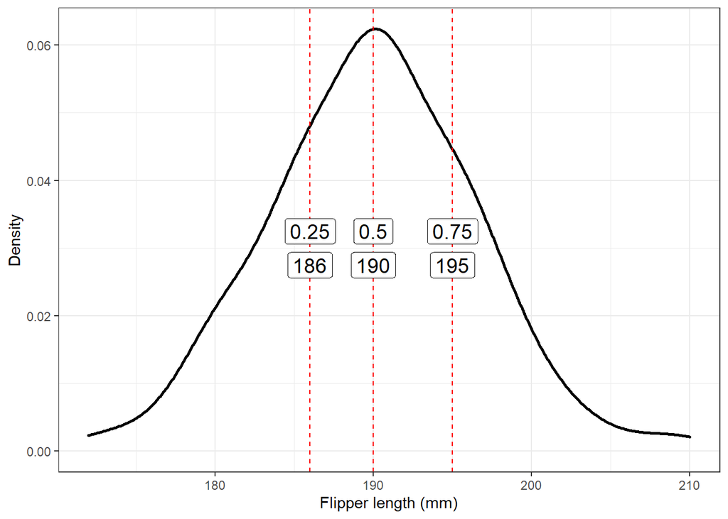

```r
probabilities <- c(0.25, 0.5, 0.75)
quantiles <- quantile(flippers, probs=probabilities, na.rm=1)

ggplot(tibble(flippers), aes(x=flippers)) + theme_bw() +
  geom_density(adjust=1, size=1) + xlab("Flipper length (mm)") + ylab("Density") +
  geom_vline(xintercept = quantiles, linetype="dashed", color="red") +
  annotate("label", x=quantiles, y=0.0325, size=5, fill="white", label= probabilities) +
  annotate("label", x=quantiles, y=0.0275, size=5, fill="white", label=quantiles)
```

```r
quantile(flippers, probs=c(0.25, 0.5, 0.75), na.rm=1)
```

```
## 25% 50% 75%
## 186 190 195
```

### In rainfall data

```r
quantile(rainfall, na.rm=1, probs=seq(from=0, to=1, by=0.1))
```

```
##    0%   10%   20%   30%   40%   50%   60%   70%   80%   90%  100%
##  0.00  0.00  0.00  0.00  0.00  0.00  0.00  0.40  4.00 12.02 42.00
```

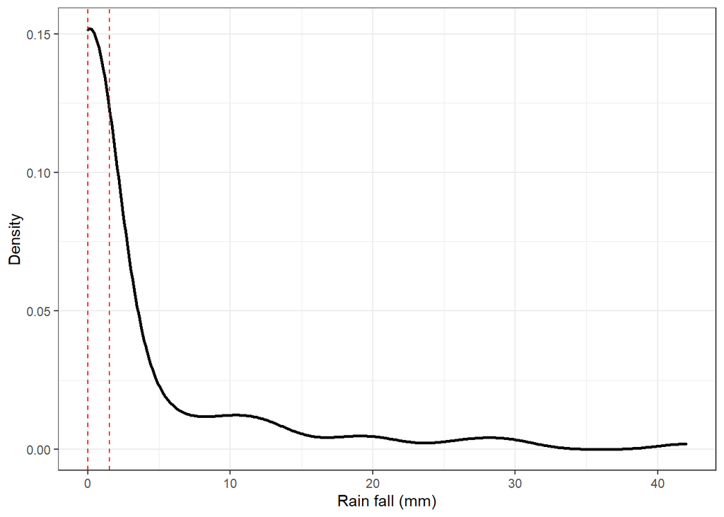

```r
probabilities <- c(0.25, 0.5, 0.75)
quantiles <- quantile(rainfall, probs=probabilities, na.rm=1)

ggplot(tibble(rainfall), aes(x=rainfall)) + theme_bw() +
  geom_density(adjust=5, size=1) + xlab("Rain fall (mm)") + ylab("Density") +
  geom_vline(xintercept=quantiles, linetype="dashed", color="red")
```

```r
quantile(rainfall, probs=c(0.25, 0.5, 0.75), na.rm=1)
```

```
## 25% 50% 75%
## 0.0 0.0 1.5
```

# Estimates of variability

Another crucial aspect of a feature in a data set is its variability or dispersion.

## The sample variance and sample standard deviation

```r
var(flippers, na.rm=1)
```

```
## [1] 42.7645
```

```r
sd(flippers, na.rm=1)
```

```
## [1] 6.539457
```

## The sample median absolute deviation

The median absolute deviation is a robust alternative to the standard deviation.

```r
mad(flippers, na.rm=1)
```

```
## [1] 7.413
```

## The sample range

just the range, but extremely sensitive to outliers

```r
diff(range(flippers, na.rm=1))
```

```
## [1] 38
```

## The interqurtile range

75%th - 25%th

```r
quantile(flippers, probs=c(0.25, 0.5, 0.75), na.rm=1)
```

```
## 25% 50% 75%
## 186 190 195
```

```r
IQR(flippers, na.rm=1)
```

```
## [1] 9
```

# Understanding box plots

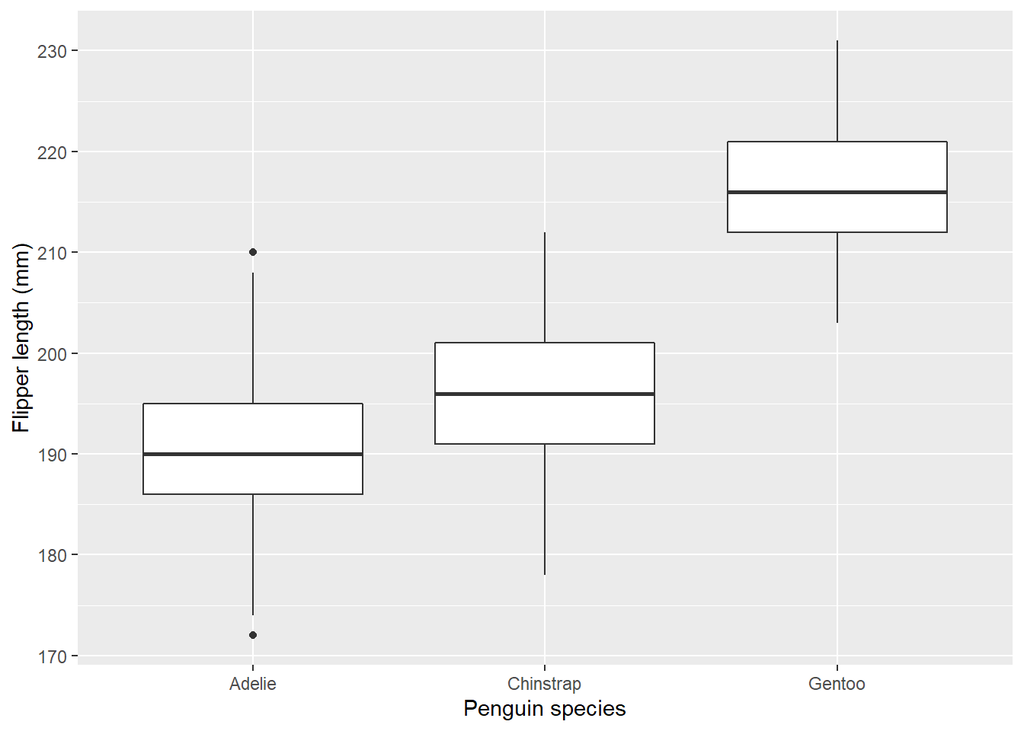

```r
ggplot(data=penguins, aes(y=flipper_length_mm, x=species)) + geom_boxplot() + ylab("Flipper length (mm)") + xlab("Penguin species")
```

## Interquartile range and outliers

```r
q25 <- quantile(flippers, 0.25, na.rm=1)
q75 <- quantile(flippers, 0.75, na.rm=1)
iq_range <- q75 - q25
outliers <- flippers[(flippers > q75 + 1.5*iq_range) | (flippers < q25 - 1.5*iq_range)]
outliers
```

```
## [1]  NA 172 210
```

# Relating variables via sample covariance and sample correlation

## Sample covariance

used to see how connected two variables or features

```r
cov(penguins$flipper_length_mm, penguins$bill_length_mm, use="complete.obs")
```

```
## [1] 50.37577
```

## Sample correlation

used to see how connected two variables or features

```r
cor(penguins$flipper_length_mm, penguins$bill_length_mm, use = "complete.obs")
```

```
## [1] 0.6561813
```

# Sample vs. population quantities

We view the data set as a sample from a much larger population of penguins

The data set is often referred to as a data sample, or just sample.

A statistic(aka sample statistics or summary statistic) is any function of the sample.

Whilst we compute sample statistics based on the data, our true interests often lie on the associated population quantity.

Making inferences about the underlying population based upon the sample lies at the heart of statistics.